# BRCA

Agnieszka Linowska, Jakub Trojgo, Mateusz Macias, Szymon Górka

9 czerwca 2016

# Baza danych

Analizę zaczeliśmy od przyjrzenia się zbiorowi danych, rozkładowi przypadków w Polsce oraz policzyliśmy kilka podstawowych statytyk.

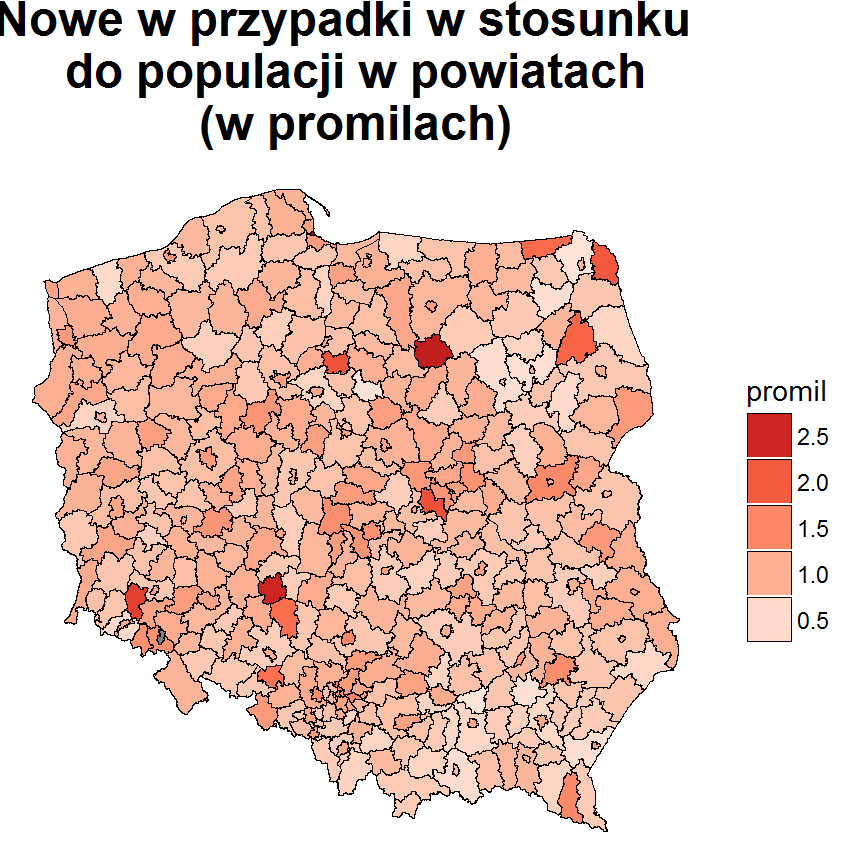

Nowe przypadki są rozłożone równomiernie na terenie całego kraju.

```
## MEAN:  0.94
```

```
## VARIANCE:  0.1
```

## Nowe przypadki pośród grup wiekowych

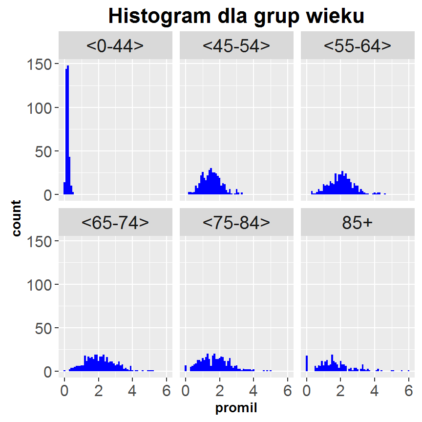

Można zauważyć zdecydowane zróżnicowanie zachorowań wśród grup wieku.

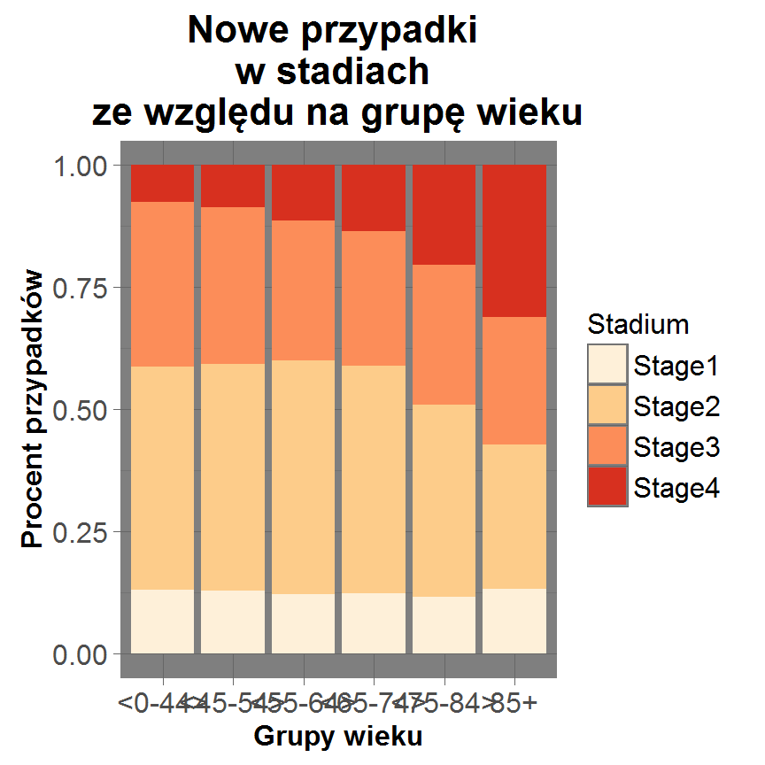

Procent nowych przypadków w stadium 3 i 4 wzrasta wraz z grupą wieku

## Stadium I i II

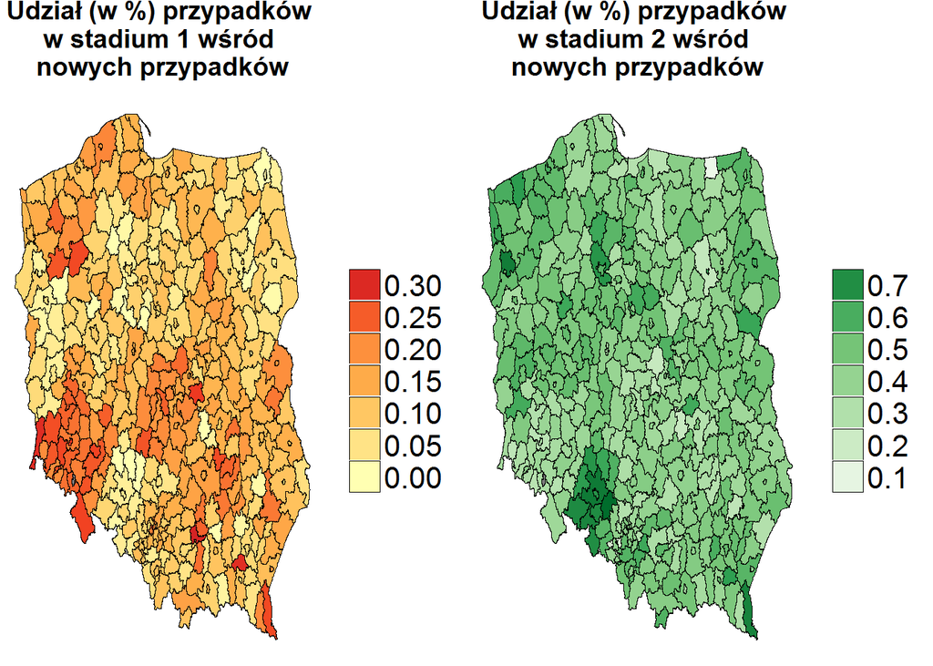

Można zauważyć, iż niektóre regiony mają prawdopodobnie lepszy program wykrywania nowych przypadków

W przypadku stadium 2 dane wskazują na większą liczbę przypadków w stadium 2 wśród nowych przypadków w województwie opolskim.

## Stadium III i IV W przypadku stadium III i IV nie stwierdziliśmy wyraźnej zależności.

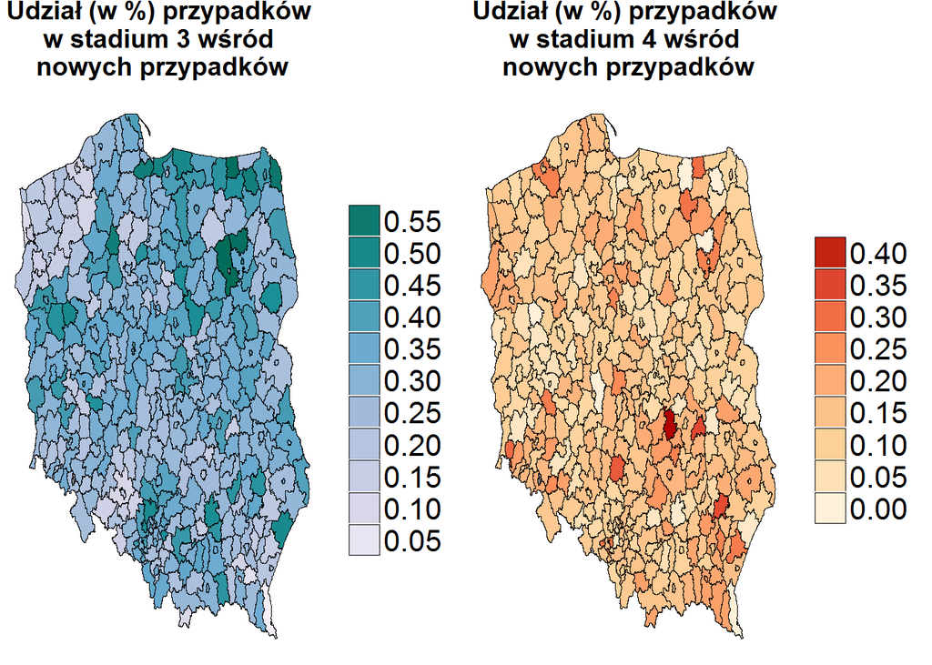

# MODEL

## Opis zmienncyh

Wykorzystaliśmy informacje o płci i wieku. Do bazy danych dodano liczbę łóżek w szpitalach na 10 tys. osób oraz liczbę ludności.

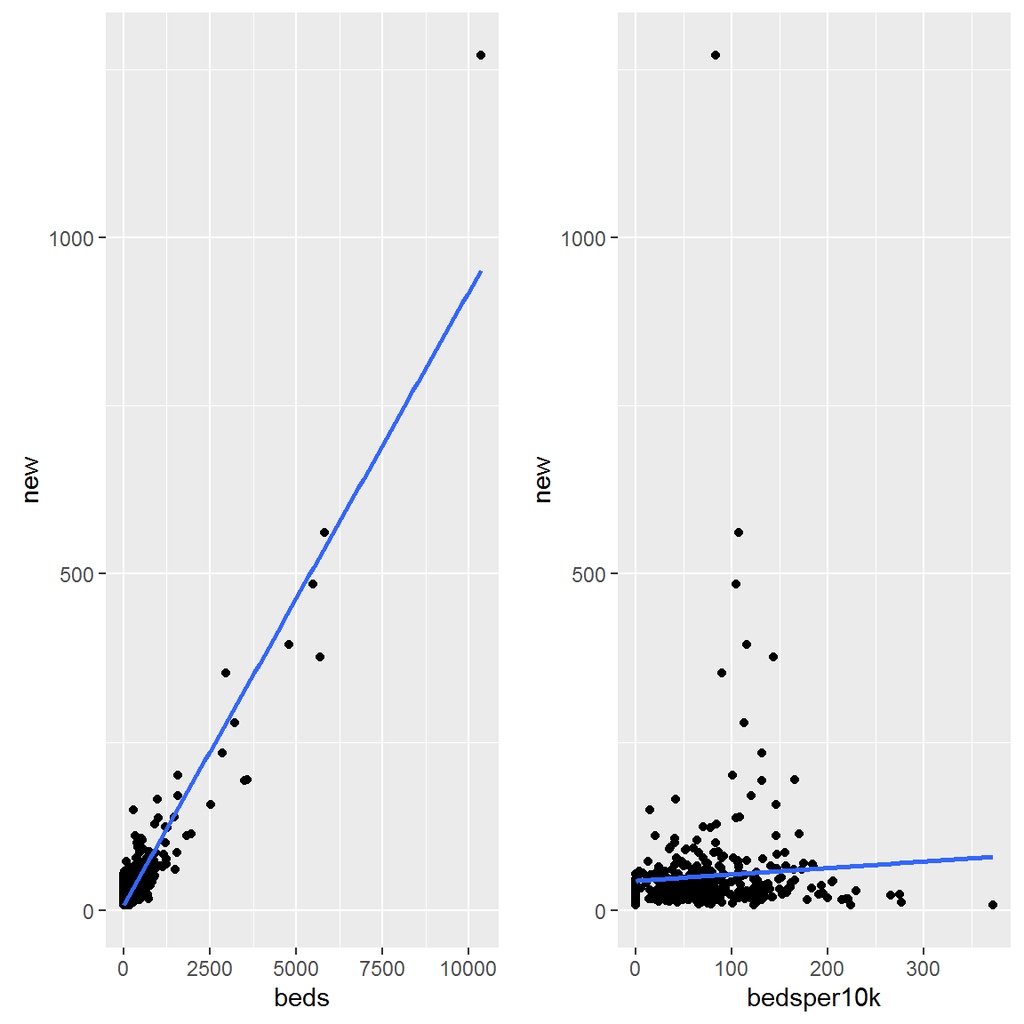